# Takehome03

Analyzing Chocolate Companies based on their location

## Introduction

Since we are trying to focus on analyzing top 15 companies, we need to do some data cleaning and preparation before analyzing.

```r
ch= read.csv("data/chocolate.csv")
```

```r
count <- ch %>%
  count(`company_location`) %>%
    arrange(desc(n)) %>%
  rename(company_number = n) %>%
     slice(seq_len(15))
```

```r
top15 <- merge(ch, count, by = 'company_location' )
```

```r
top15$cocoa_percent <- as.numeric(sub("%", "",top15$cocoa_percent,fixed=TRUE))/100
```

## Variable Analysis

Since we are trying to analyze two variables in this task. We could just plot a simple graph to check whether there is a linear relation between these two factors. In other words, we want to see whether customers would leave a high rating for chocolate with high cocoa percentage

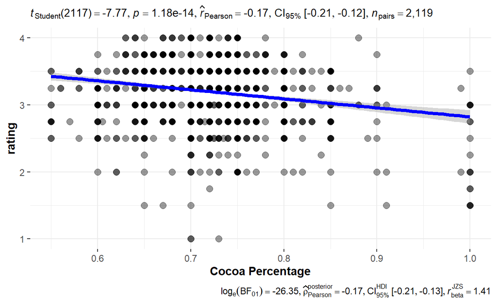

```r
ggscatterstats(
  data = top15,
  x = cocoa_percent,
  y = rating,
  marginal = FALSE,
  )+labs(x= "Cocoa Percentage")
```

We could see that there is a slightly negative relation between those two variables. It might be because that chocolates with lower Cocoa Percentage is sweeter, which is more welcome to people.

## Construct Confidence Interval for chocolate rating

We could also check whether there is significant difference in rating based on various chocolate producing location.

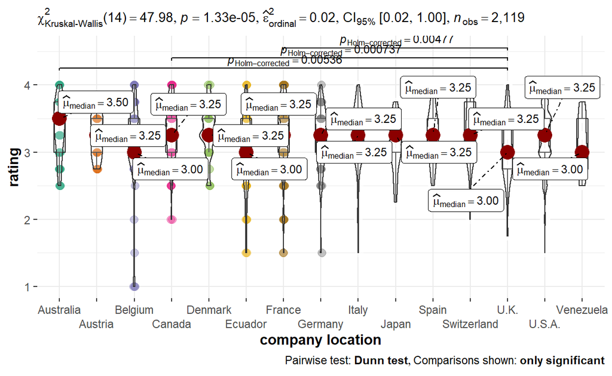

```r
ggbetweenstats(
  data = top15,
  x = company_location,
  y = rating,
  type = "np",
  messages = TRUE
)+
  scale_x_discrete("company location",guide = guide_axis(n.dodge=2))
```

Based on the graph we plot, we could say that chocolate from U.K. might received slightly different rating compare to Australia, Canada and France.

construct the 95% confidence interval applying formula below:

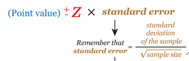

```r
rating <- top15 %>%
  group_by(company_location) %>%
  summarise(
    n=n(),
    mean=mean(rating),
    sd=sd(rating)
    ) %>%
  mutate(se=sd/sqrt(n-1))
```

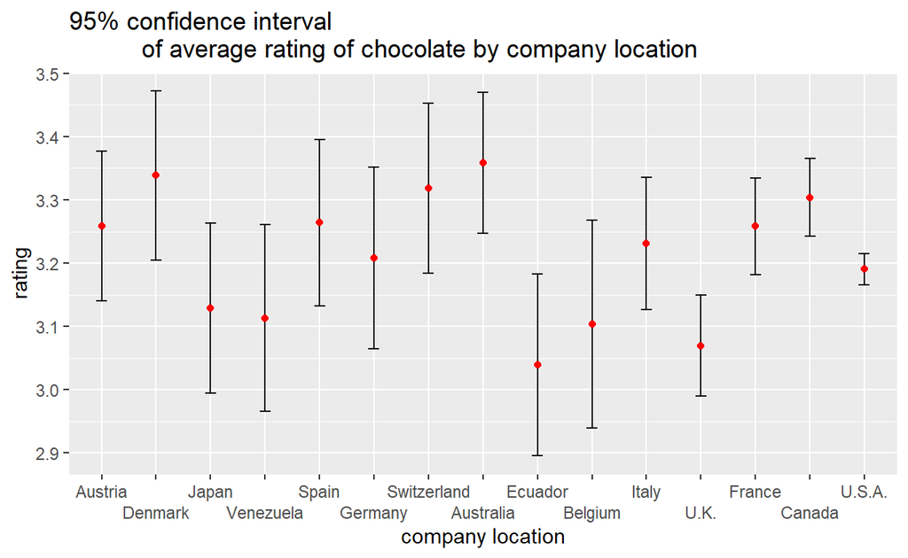

```r
ggplot(rating) +
  geom_errorbar(
    aes(x=reorder(company_location, n),  #Sort countries based on number of companies in the country in ascending order rather than alphabetical order
        ymin=mean-1.96*se,
        ymax=mean+1.96*se),
    width=0.2,
    colour="black",
    alpha=0.9,
    size=0.5) +
  geom_point(aes
           (x=company_location,
            y=mean),
           stat="identity",
           color="red",
           size = 1.5,
           alpha=1) +
  scale_x_discrete("company location",guide = guide_axis(n.dodge=2))+
  labs(y= "rating")+
  ggtitle("95% confidence interval
          of average rating of chocolate by company location")
```

We sort those company location country based on sample size In general, as sample size(n) increases the range of confidence interval we built get smaller. In other words, we are 95% confident to say that the real rating for chocolate is included in our interval.

## Construct Confidence Interval for Proportion

Proportion test requires us to apply another formula:

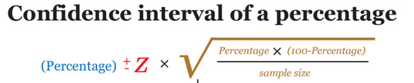

```r
percent <- top15 %>%
  group_by(company_location) %>%
  filter(cocoa_percent>0.7) %>%
  summarise(over=n())
```

```r
pro <- merge(percent,count, by = 'company_location' )%>%
  rename(size=company_number)
pro$prop<- pro$over/pro$size
```

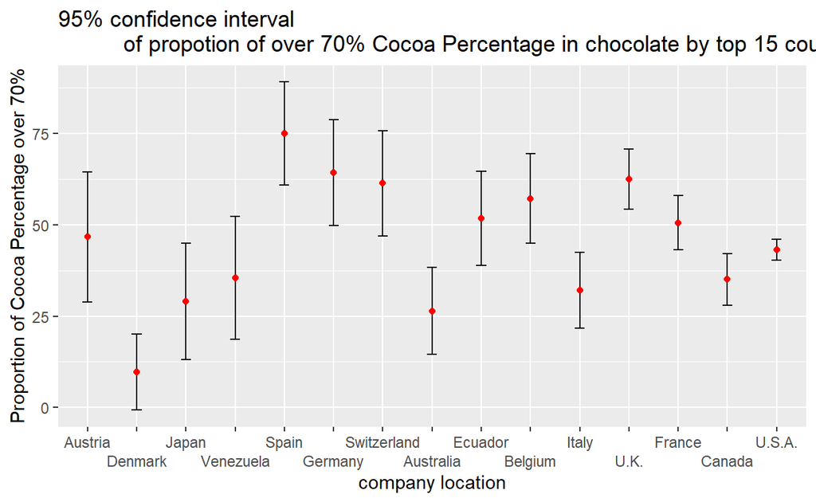

```r
ggplot(pro) +
  geom_errorbar(
    aes(x=reorder(company_location, size),
        ymin=(prop-1.96*sqrt((prop*(1-prop))/size))*100,
        ymax=(prop+1.96*sqrt((prop*(1-prop))/size))*100),
    width=0.2,
    colour="black",
    alpha=0.9,
    size=0.5) +
  geom_point(aes
           (x=company_location,
            y=prop*100),
           stat="identity",
           color="red",
           size = 1.5,
           alpha=1) +
  scale_x_discrete("company location",guide = guide_axis(n.dodge=2))+
  labs(y= "Proportion of Cocoa Percentage over 70%")+
  ggtitle("95% confidence interval
          of propotion of over 70% Cocoa Percentage in chocolate by top 15 country")
```

Based on the graph we construct, we could say that we are 95% confident that the real proportion of producing chocolate with above 70% cocoa percentage for individual country is inside our interval .